# p8105_hw5_lk2776

2024-11-05

```r
#load packages
library(tidyverse)
library(ggridges)
library(patchwork)
library(purrr)
library(broom)
library(ggplot2)

#R figure settings
knitr::opts_chunk$set(
  fig.width = 9,
  fig.asp = .6,
  out.width = "90%"
)
theme_set(theme_minimal() + theme(legend.position = "bottom"))

options(
  ggplot2.continuous.colour = "viridis",
  ggplot2.continuous.fill = "viridis"
)

scale_colour_discrete = scale_colour_viridis_d
scale_fill_discrete = scale_fill_viridis_d
```

## problem1

```r
b_day_func = function(group_size) {
  #random birthday generation for each group
  sim_b_data = sample(1:365, group_size, replace=TRUE)

  any(duplicated(sim_b_data)) #check - one output
}

b_day_func(1)
```

```
## [1] FALSE
```

```r
b_day_func(100)
```

```
## [1] TRUE
```

```r
sim_results_df_p1 =
  expand_grid(
    group_sizes = seq(2,50),
    iter = 1:10000) |>
  mutate(
    output_p1 = map_lgl(group_sizes, \(x) b_day_func(x))
    ) |>
   group_by(group_sizes) |>
  summarize(prob_dup = mean(output_p1))
```

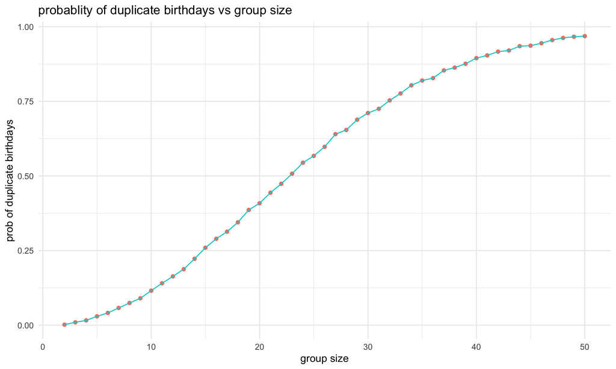

```r
ggplot(sim_results_df_p1,aes(x = group_sizes, y = prob_dup)) +
       geom_point(color="salmon") +
         geom_line(color="cyan3") +
  labs(
    title = "probablity of duplicate birthdays vs group size",
    x = "group size",
    y = "prob of duplicate birthdays"
  )
```

## problem 2

```r
#function
sim_mean_sd = function(n =30, mu, sigma = 5) {
  sim_data = tibble(
    x = rnorm(n, mean = mu, sd = sigma)
)

  t_test_out <- t.test(sim_data$x, mu = 0) #null

  tidy(t_test_out)|>
    select(estimate, p.value)
}
#Run function on data mu = 0
sim_results_df =
  expand_grid(
    mu_given = 0,
    iter = 1:5000
  ) |>
  mutate(
    estimate_df = map(mu_given, \(x) sim_mean_sd(mu = x))
  ) |>
  unnest(estimate_df)
```

```r
#Run function on data
sim_results_df_b =
  expand_grid(
    #sample_size = 30,
    mu_given = c(1,2,3,4,5,6),
    iter = 1:5000
  ) |>
  mutate(
    estimate_df = map(mu_given, \(x) sim_mean_sd(mu = x))
  ) |>
  unnest(estimate_df)
sim_results_df_all <- bind_rows(sim_results_df,sim_results_df_b)
```

As shown in the plot below, as the true value of mu increases, the power of the test also increases, reaching 1. Effect size is defined as the difference between sample mean and the hypothesized mean(mu = 0). Therefore, as the true mean increases, the effect size becomes larger. This increase in effect size, increases the ability of the test to correctly detect the true effect and correctly reject the null hypothesis. As a result, power of the test also increases with larger true mean values.

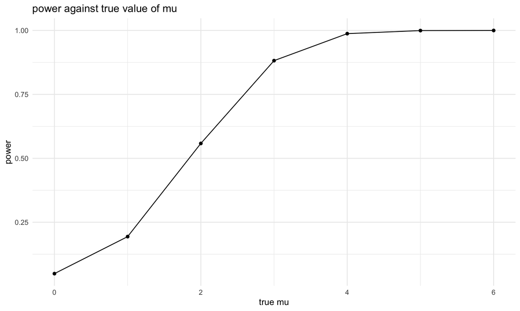

```r
new_df = sim_results_df_all |>
  mutate(reject_null = p.value < 0.05) |>
  group_by(mu_given) |>
  summarise(power_calc = mean(reject_null)) #power for each value of mu # proportion of times the null was rejected.

ggplot(new_df,aes(x = mu_given, y = power_calc)) +
  geom_point() +
  geom_line() +
  labs(
    title = "power against true value of mu",
    x = "true mu",
    y = "power"
  )
```

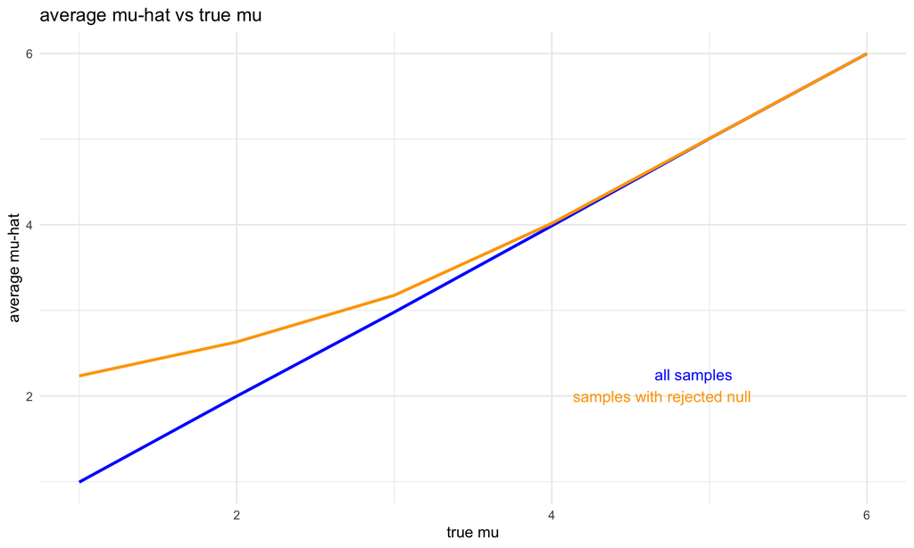

```r
new_df_b = sim_results_df_b |>
  group_by(mu_given) |>
  summarize(
    avg_mu_hat = mean(estimate),
    avg_mu_hat_rejected = mean(estimate[p.value <0.05]))

ggplot(new_df_b, aes(x = mu_given))+
  geom_line(aes(y=avg_mu_hat),color="blue", size = 1) +
  geom_line(aes(y=avg_mu_hat_rejected), color="orange", size =1)+
  labs(
    title = "average mu-hat vs true mu",
    x = "true mu",
    y = "average mu-hat",
  ) +
  annotate("text", x = 4.7, y = 2, label = "samples with rejected null", color = "orange") +
  annotate("text", x = 4.9, y = 2.25, label = "all samples", color = "blue")
```

## problem3

```r
#read data
data = read_csv("./data/homicide-data.csv") |>
  janitor::clean_names() |>
  drop_na()
```

The number of rows and columns in the homicides data: **[52,119 x 12]** The column variables are: **uid, reported_date, victim_last, victim_first, victim_race, victim_age, victim_sex, city, state, lat, lon, disposition** . The dataset includes information about victim, reported date of homicide, location of homicide, and status of the case.

```r
summary_data = data |>
  mutate(city_state = paste(city, state, sep="_"),
         not_solved = if_else(
           disposition %in% c("Closed without arrest", "Open/No arrest"), 1, 0))  |> # if match, add 1, otherwise, add 0.
  group_by(city_state) |>
  summarize(
    total_number_of_homicides = n(), #count
    unsolved_homicides = sum(not_solved)
  ) #|>
  #knitr::kable()
head(summary_data)
```

```
## # A tibble: 6 × 3
##   city_state     total_number_of_homicides unsolved_homicides
##   <chr>                              <int>              <dbl>
## 1 Albuquerque_NM                       375                144
## 2 Atlanta_GA                           973                373
## 3 Baltimore_MD                        2827               1825
## 4 Baton Rouge_LA                       424                196
## 5 Birmingham_AL                        799                346
## 6 Boston_MA                            612                309
```

```r
#baltimore prop test
summary_data_baltimore = summary_data |>
  filter(city_state == "Baltimore_MD")

prop_test_out_balti = prop.test(summary_data_baltimore$unsolved_homicides,summary_data_baltimore$total_number_of_homicides)

tidy(prop_test_out_balti) |>
  select(estimate,conf.low,conf.high) |>
  knitr::kable()
```

| estimate | conf.low | conf.high |
| --- | --- | --- |
| 0.6455607 | 0.6275625 | 0.6631599 |

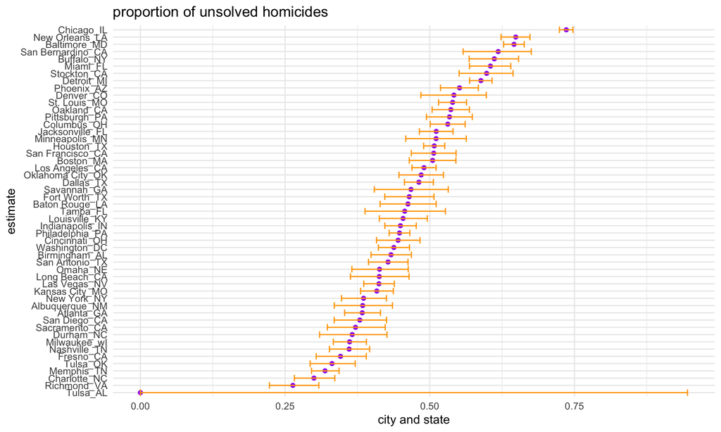

```r
#all cities prop test
prop_results_all_cities = summary_data |>
  mutate(prop_test_out_all = map2(unsolved_homicides,total_number_of_homicides, \(x,y) prop.test(x,y)),
         tidy_df = map(prop_test_out_all,tidy))|>
  unnest(tidy_df) |>
  select(city_state,estimate,conf.low,conf.high)
prop_results_all_cities |>
 mutate(city_state = fct_reorder(city_state,estimate)) |>
  ggplot(aes(x = city_state, y = estimate)) +
  geom_point(color="purple") +
  geom_errorbar(aes(ymin=conf.low, ymax = conf.high), color = "orange") +
  coord_flip() + #to facilitate the viewing - otherwise - x-axis crowded
  labs(
    title = "proportion of unsolved homicides",
    x = "estimate",
    y = "city and state",
  )
```